# Project 2 - Hyunsoo Jace Lee, Joshua Schopmeyer

### Getting Started

In this project, we aim to evaluate the performance of teams in the English Premier League during the 2018–2019 season. Our goal is to understand how different factors contributed to team success or struggles throughout the season. By analyzing match statistics such as points per game, goals scored at home, and performance differences between home and away matches, we can gain deeper insight into what influenced each club’s standing. Specifically, we investigate patterns such as home-field advantage, scoring efficiency, and consistency across venues to determine which metrics best explain overall team performance. We can also analyze certain statistics and trends in data to determine what statistics are most valuable and contribute most to winning games and scoring goals. Through visualizations and statistical analysis, this project reveals the dynamics that defined one of the world’s most competitive football leagues.

### Importing the Data

```python
import numpy as np
import pandas as pd
import seaborn as sns
import matplotlib.pyplot as plt
import requests
from bs4 import BeautifulSoup

df = pd.read_csv('/Users/jacelee/Desktop/301/england-premier-league-teams-2018-to-2019-stats.csv')
print(df.head())
```

```
              team_name        common_name     season  country  \
0            Arsenal FC            Arsenal  2018/2019  England
1  Tottenham Hotspur FC  Tottenham Hotspur  2018/2019  England
2    Manchester City FC    Manchester City  2018/2019  England
3     Leicester City FC     Leicester City  2018/2019  England
4     Crystal Palace FC     Crystal Palace  2018/2019  England

   matches_played  matches_played_home  matches_played_away  \
0              38                   19                   19
1              38                   19                   19
2              38                   19                   19
3              38                   19                   19
4              38                   19                   19

   suspended_matches  wins  wins_home  ...  goals_conceded_min_61_to_70  \
```

[output cut: 35 more lines]

First, we're going to implement some tools we'll need to complete this analysis, such as pandas to create a dataframe, and matplotlib to help us visualize our data and reach some conclusions, and then we will load in our dataset.

To get this dataset, we used a CSV file taken from 'footystats.org' of statistics about teams in the 2018-19 Premier League football season. Once we downloaded the CSV, we took the path to the file on the computer, and using pandas, used a read_csv function to have Python read all the data within the CSV, allowing us to utilize it within this project. We also printed the head of the data to get an early look and make sure everything was functioning correctly.

```python
print(df.info())
```

```
<class 'pandas.core.frame.DataFrame'>
RangeIndex: 20 entries, 0 to 19
Columns: 293 entries, team_name to over145_corners_percentage
dtypes: float64(36), int64(253), object(4)
memory usage: 45.9+ KB
None
```

```python
print(df.columns)
print(df.describe())
```

```
Index(['team_name', 'common_name', 'season', 'country', 'matches_played',
       'matches_played_home', 'matches_played_away', 'suspended_matches',
       'wins', 'wins_home',
       ...
       'goals_conceded_min_61_to_70', 'goals_conceded_min_71_to_80',
       'goals_conceded_min_81_to_90', 'draw_percentage_overall',
       'draw_percentage_home', 'draw_percentage_away',
       'loss_percentage_ovearll', 'loss_percentage_home',
       'loss_percentage_away', 'over145_corners_percentage'],
      dtype='object', length=293)
       matches_played  matches_played_home  matches_played_away  \
count            20.0                 20.0                 20.0
mean             38.0                 19.0                 19.0
std               0.0                  0.0                  0.0
min              38.0                 19.0                 19.0
25%              38.0                 19.0                 19.0
50%              38.0                 19.0                 19.0
75%              38.0                 19.0                 19.0
max              38.0                 19.0                 19.0

       suspended_matches       wins  wins_home  wins_away     draws  \
count               20.0  20.000000  20.000000  20.000000  20.00000
mean                 0.0  15.450000   9.050000   6.400000   7.10000
std                  0.0   7.250953   4.019361   3.560012   2.44734
min                  0.0   3.000000   2.000000   1.000000   2.00000
25%                  0.0  10.750000   6.000000   4.000000   6.75000
50%                  0.0  14.500000   8.000000   6.000000   7.00000
75%                  0.0  19.500000  10.500000   9.000000   9.00000
max                  0.0  32.000000  18.000000  14.000000  12.00000

       draws_home  draws_away  ...  goals_conceded_min_61_to_70  \
count    20.00000    20.00000  ...                    20.000000
mean      3.55000     3.55000  ...                     6.650000
std       1.90498     1.79106  ...                     2.960708
min       0.00000     0.00000  ...                     3.000000
25%       2.00000     2.00000  ...                     4.000000
50%       3.00000     4.00000  ...                     7.000000
75%       5.00000     5.00000  ...                     8.250000
max       8.00000     8.00000  ...                    12.000000

```

[output cut: 26 more lines]

```
50%                  42.000000             32.000000             42.000000
75%                  50.750000             48.500000             59.250000
max                  74.000000             74.000000             84.000000

       over145_corners_percentage
count                   20.000000
mean                     7.450000
std                      4.382681
min                      0.000000
25%                      5.000000
50%                      8.000000
75%                     11.000000
max                     16.000000

[8 rows x 289 columns]
```

### Data Cleaning

We can look into cleaning up this data set, however, since we took it from an official site with organized and professional data, there is likely not much to remove or work to clean up.

```python
df.isnull().values.any()
```

```
False
```

```python
print(df.isnull().sum())
```

```
team_name                     0
common_name                   0
season                        0
country                       0
matches_played                0
                             ..
draw_percentage_away          0
loss_percentage_ovearll       0
loss_percentage_home          0
loss_percentage_away          0
over145_corners_percentage    0
Length: 293, dtype: int64
```

First, we checked simply to see if there are any null values within the data set we pulled, and there weren't, meaning there isn't anything to remove from the data set to make sure it all runs and functions properly. Just to confirm, we asked Python to print the sum of the count of null values within the data frame. As we can determine from this, the data seems to be fully cleaned up and ready for use in undergoing analysis and manipulation.

### Data Analysis / Visualizing the Relationships

The first thing we're going to explore is the impact of goals scored and goals conceded in the Premier League in 2018-19. We created a data frame that lists all 20 teams in the Premier League this season, and included their final league position in the table, and then their goals scored, goals conceded and the goal difference, which subtracts goals conceded from goals scored to see which team had the biggest gap between the two, essentially who had the best of both worlds. We will sort by league position to mimmick how an actual standings table would look.

```python
df[['common_name', 'league_position', 'goals_scored', 'goals_conceded', 'goal_difference']].sort_values(by='league_position')
```

|  | common_name | league_position | goals_scored | goals_conceded | goal_difference |
| --- | --- | --- | --- | --- | --- |
| 2 | Manchester City | 1 | 95 | 23 | 72 |
| 10 | Liverpool | 2 | 89 | 22 | 67 |
| 11 | Chelsea | 3 | 63 | 39 | 24 |
| 1 | Tottenham Hotspur | 4 | 67 | 39 | 28 |
| 0 | Arsenal | 5 | 73 | 51 | 22 |
| 9 | Manchester United | 6 | 65 | 54 | 11 |
| 19 | Wolverhampton Wanderers | 7 | 47 | 46 | 1 |
| 5 | Everton | 8 | 54 | 46 | 8 |
| 3 | Leicester City | 9 | 51 | 48 | 3 |
| 12 | West Ham United | 10 | 52 | 55 | -3 |
| 13 | Watford | 11 | 52 | 59 | -7 |
| 4 | Crystal Palace | 12 | 51 | 53 | -2 |
| 14 | Newcastle United | 13 | 42 | 48 | -6 |
| 8 | AFC Bournemouth | 14 | 56 | 70 | -14 |
| 6 | Burnley | 15 | 45 | 68 | -23 |
| 7 | Southampton | 16 | 45 | 65 | -20 |
| 17 | Brighton & Hove Albion | 17 | 35 | 60 | -25 |
| 15 | Cardiff City | 18 | 34 | 69 | -35 |
| 16 | Fulham | 19 | 34 | 81 | -47 |
| 18 | Huddersfield Town | 20 | 22 | 76 | -54 |

As we can see from the table, there seems to be a strong relationship between having a high goal difference and finishing near the top of the table. Manchester City and Liverpool, the top two teams in the table, finished with a significantly higher goal difference than any other team. Meanwhile, the bottom 3 teams in goal difference finished bottom 3 in the table as well. This intuitively makes sense. Scoring goals is good, allowing goals is bad. This is reflected well in the data.

### Analysis of Goals Scored and Conceded

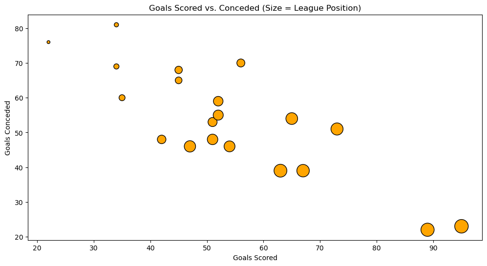

```python
plt.figure(figsize=(12, 6))

sizes = (21 - df['league_position']) * 20

plt.scatter(
    df['goals_scored'],
    df['goals_conceded'],
    s=sizes,
    color= 'orange',
    edgecolors='black'
)

plt.xlabel('Goals Scored')
plt.ylabel('Goals Conceded')
plt.title('Goals Scored vs. Conceded (Size = League Position)')
```

We can visualize this through a scatter plot, with goals conceded on the y-axis and goals scored on the x-axis. We will also add a size scale to our markers in order to represent league position, with larger being higher up the table. As we can see, the scatter plot is quite linear, with teams that score the most goals also tend to allow the fewest.

### Analysis of Goal Difference and League Position

```
Correlation between Goal Difference and League Position: -0.9437432059863963
Correlation between Goals Scored and Conceded: -0.8311003935432062
```

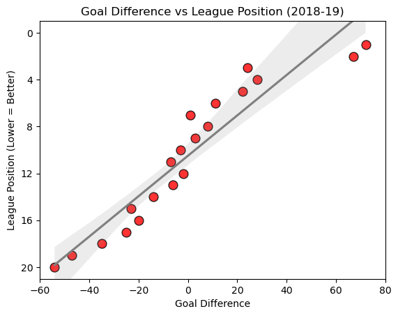

```python
sns.regplot(
    x = 'goal_difference',
    y = 'league_position',
    data = df,
    scatter_kws={'s': 85, 'color': 'red', 'edgecolor': 'black'},
    line_kws={'color': 'grey'}
)

plt.xlabel('Goal Difference')
plt.ylabel('League Position (Lower = Better)')
plt.title('Goal Difference vs League Position (2018-19)')

plt.xlim(-60, 80)
plt.ylim(21, -1)
plt.yticks(ticks=range(0,22,4))


correlation_goal_lg = df['goal_difference'].corr(df['league_position'])
correlation_score_concede = df['goals_scored'].corr(df['goals_conceded'])
print(f"Correlation between Goal Difference and League Position: {correlation_goal_lg}")
print(f"Correlation between Goals Scored and Conceded: {correlation_score_concede}")
```

We can also visualize this importance of goal difference by directly comparing goal difference to league position. This provides a very similar conclusion to the last plot, but instead league position is represented on the y-axis, and goals are only represented on one axis through goal difference. This provides us with a clear idea- goal difference is the most important underlying metric when it comes to trying to place highly on the Premier League table.

### Analysis of Premier League Home vs Away Performance

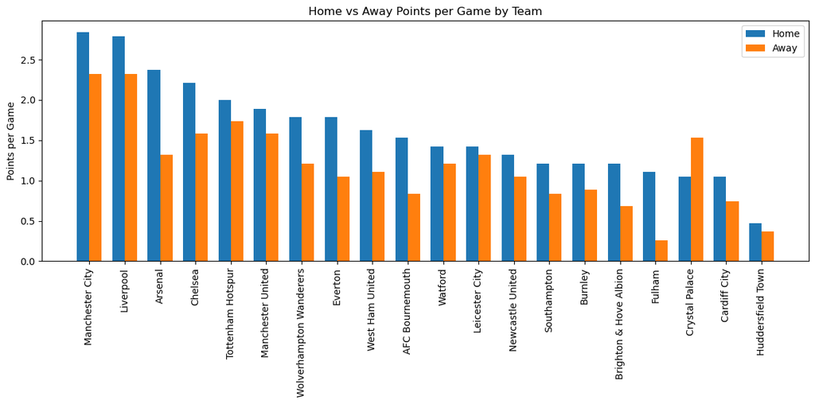

```python
plt.figure(figsize=(12,6))
df_sorted = df.sort_values(by='points_per_game_home', ascending=False)
x = np.arange(len(df_sorted))
width = 0.35

plt.bar(x - width/2, df_sorted['points_per_game_home'], width=width, label='Home')
plt.bar(x + width/2, df_sorted['points_per_game_away'], width=width, label='Away')
plt.xticks(ticks=x, labels=df_sorted['common_name'], rotation=90)
plt.ylabel("Points per Game")
plt.title("Home vs Away Points per Game by Team")
plt.legend()
plt.tight_layout()
plt.show()
```

The bar graph visualizes home and away points per game (PPG) for Premier League teams in the 2018–2019 season, clearly highlighting which teams benefited most from home-field advantage. At the top of the chart, **Manchester City** and **Liverpool** stand out as the strongest home performers, each earning close to 3.0 PPG at home. While both teams also performed well away, the slight drop in their away PPG suggests a modest but real home advantage. **Arsenal**, however, exhibits one of the most striking differences between home and away performance. While their home record is among the league’s best, their away PPG is significantly lower, reflecting a strong reliance on their home fixtures for success.

At the bottom of the chart, **Fulham**, **Cardiff City**, and especially **Huddersfield Town** show consistently poor performance both at home and away. Huddersfield Town, in particular, has the lowest PPG overall, reflecting significant struggles regardless of location.

This visualization effectively highlights both dominant and struggling teams, while also showcasing outliers like Crystal Palace whose performance bucks the typical home advantage trend.

### Data Manipulation

```python
df['home_minus_away_points'] = df['points_per_game_home'] - df['points_per_game_away']
df[['common_name', 'home_minus_away_points']].sort_values(by='home_minus_away_points', ascending=False)
```

|  | common_name | home_minus_away_points |
| --- | --- | --- |
| 0 | Arsenal | 1.05 |
| 16 | Fulham | 0.85 |
| 5 | Everton | 0.74 |
| 8 | AFC Bournemouth | 0.69 |
| 11 | Chelsea | 0.63 |
| 19 | Wolverhampton Wanderers | 0.58 |
| 17 | Brighton & Hove Albion | 0.53 |
| 2 | Manchester City | 0.52 |
| 12 | West Ham United | 0.52 |
| 10 | Liverpool | 0.47 |
| 7 | Southampton | 0.37 |
| 6 | Burnley | 0.32 |
| 15 | Cardiff City | 0.31 |
| 9 | Manchester United | 0.31 |
| 14 | Newcastle United | 0.27 |
| 1 | Tottenham Hotspur | 0.26 |
| 13 | Watford | 0.21 |
| 18 | Huddersfield Town | 0.10 |
| 3 | Leicester City | 0.10 |
| 4 | Crystal Palace | -0.48 |

Using data manipulation, we can numerically see which teams are performing much better at home compared to away, essentially telling us which teams relied on the home field advantage factor the most in order to win games. As mentioned previously Arsenal have a striking gap between their home and away performance, averaging over a point more per game in their home fixtures compared to away fixtures. Fulham and Everton also show very significant differences in home and away performance, while Crystal Palace away dominance continues to be a spectacle in the data.

### Analysis of Home Goals vs Points per Game

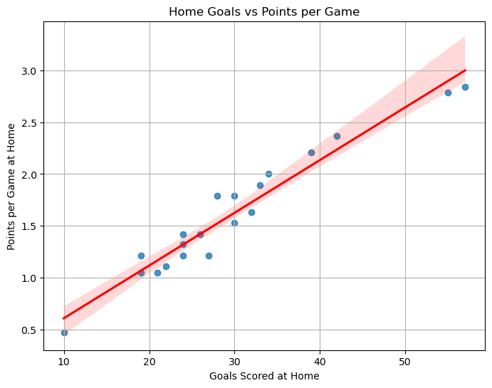

```python
plt.figure(figsize=(8,6))
sns.regplot(x='goals_scored_home', y='points_per_game_home', data=df, line_kws={"color": "red"})
plt.title("Home Goals vs Points per Game")
plt.xlabel("Goals Scored at Home")
plt.ylabel("Points per Game at Home")
plt.grid(True)
plt.show()
```

The scatter plot illustrates the relationship between the number of goals scored at home and the points per game (PPG) earned at home by Premier League teams in the 2018–2019 season. A clear upward trend is visible: teams that scored more goals at home generally earned more points per game. This positive correlation suggests that offensive effectiveness at home is a strong determinant of overall home performance.

At the lower left of the plot, we see teams that scored fewer than 20 goals at home, and most of them earned below 1.5 PPG. These are likely the struggling teams in the league, as their lack of home goals translates to fewer match wins and draws. In contrast, teams on the upper right (scoring 40 or more goals at home) consistently earned over 2.0 PPG, indicating top-tier performance, likely including clubs such as Manchester City or Liverpool.

The plot also shows a fairly linear trend, meaning each increase in home goals is generally associated with a steady increase in points earned. This emphasizes how critical the scoring ability is in securing results, especially in home matches where teams often have the advantage of fan support and familiar conditions.

Overall, this visualization reinforces that a strong attacking presence at home directly contributes to higher league performance. Teams that fail to convert chances at home are significantly disadvantaged in the standings.

### Data / Correlation Explanation

Next, let's take a look at some more in-play specific stats. We already determined that goals were crucial to winning games in the Premier League; however, how are these goals created? They are created through shots on goal, and in order for the shot to go in, it is a requirement for it to at least be on target, meaning its trajectory was headed within the goal. This does not account for whether the shot went in or not, however. We'll be looking at which Premier League teams were the most accurate with their shots, and if it played a significant role in team and scoring success.

```python
df['shot_accuracy'] = df['shots_on_target'] / df['shots']
df[['common_name', 'goals_scored', 'shots', 'shots_on_target', 'shot_accuracy']].sort_values(by='shot_accuracy', ascending=False)
```

|  | common_name | goals_scored | shots | shots_on_target | shot_accuracy |
| --- | --- | --- | --- | --- | --- |
| 9 | Manchester United | 65 | 434 | 263 | 0.605991 |
| 2 | Manchester City | 95 | 527 | 298 | 0.565465 |
| 10 | Liverpool | 89 | 472 | 264 | 0.559322 |
| 0 | Arsenal | 73 | 377 | 208 | 0.551724 |
| 13 | Watford | 52 | 347 | 188 | 0.541787 |
| 8 | AFC Bournemouth | 56 | 375 | 200 | 0.533333 |
| 12 | West Ham United | 52 | 365 | 194 | 0.531507 |
| 11 | Chelsea | 63 | 446 | 236 | 0.529148 |
| 3 | Leicester City | 51 | 420 | 222 | 0.528571 |
| 5 | Everton | 54 | 396 | 207 | 0.522727 |
| 7 | Southampton | 45 | 383 | 200 | 0.522193 |
| 1 | Tottenham Hotspur | 67 | 433 | 226 | 0.521940 |
| 14 | Newcastle United | 42 | 366 | 178 | 0.486339 |
| 6 | Burnley | 45 | 309 | 150 | 0.485437 |
| 16 | Fulham | 34 | 376 | 181 | 0.481383 |
| 18 | Huddersfield Town | 22 | 324 | 154 | 0.475309 |
| 15 | Cardiff City | 34 | 342 | 162 | 0.473684 |
| 19 | Wolverhampton Wanderers | 47 | 397 | 188 | 0.473552 |
| 4 | Crystal Palace | 51 | 392 | 184 | 0.469388 |
| 17 | Brighton & Hove Albion | 35 | 320 | 143 | 0.446875 |

```python
correlation_shot_accuracy = df['shot_accuracy'].corr(df['points_per_game'])
correlation_shot_accuracy2 = df['shot_accuracy'].corr(df['goals_scored'])
print(f"Correlation between Shot Accuracy and Points per Game: {correlation_shot_accuracy}")
print(f"Correlation between Shot Accuracy and Goals Scored: {correlation_shot_accuracy2}")
```

```
Correlation between Shot Accuracy and Points per Game: 0.6894159873854927
Correlation between Shot Accuracy and Goals Scored: 0.7613845338364889
```

Manchester United, Manchester City, Liverpool and Arsenal, the top 4 teams in shot accuracy, all finished within top 6 of the table, suggesting a high shot accuracy indicates a strong team. However, the bottom 3 teams in the table, Cardiff, Fulham and Huddersfield, did not appear in the bottom 3 of shot accuracy, indicating that their may be other factors in play here that haven't been considered. When we run a correlation function between shot accuracy and both points per game and goals scored, it correlates stronger to goals scored. This makes sense, as it is solely keeping track of an offensive statistic, and therefore does not consider the defensive performance of a team.

```python
df['shot_conversion'] = df['goals_scored'] / df['shots_on_target']
df[['common_name', 'goals_scored', 'shots_on_target', 'shot_accuracy', 'shot_conversion']].sort_values(by='shot_conversion', ascending=False)

correlation_shot_conversion = df['shot_conversion'].corr(df['points_per_game'])
correlation_shot_conversion2 = df['shot_conversion'].corr(df['goals_scored'])
print(f"Correlation between Shot Conversion and Points per Game: {correlation_shot_conversion}")
print(f"Correlation between Shot Conversion and Goals Scorred: {correlation_shot_conversion2}")
```

```
Correlation between Shot Conversion and Points per Game: 0.7893453406196607
Correlation between Shot Conversion and Goals Scorred: 0.8292722968767772
```

The missing factor from before may be the conversion of these shots on target into actual goals. This prioritizes accuracy on the goal in this case, because not only does a goal require a shot on target, it requires it to be hit with precision so the ball gets past the goalkeeper as well. We find this by dividing goals scored by all of the shots on target to find our shot conversion rate. As we can see, Arsenal, Liverpool, and Manchester City, three common successful names in this analysis once again rank at the top of the list, while now our 3 bottom teams from the table have moved back down to the very bottom of the list, suggesting this metric is more useful and indicative than shot accuracy. The correlation is extremely high between shot conversion and goals scored, meaning this is a very good indicator of goal-scoring ability and overall team success.

### Analysis of Shot Conversion Rate per Team

```
([0, 1, 2, 3, 4, 5, 6, 7, 8, 9, 10, 11, 12, 13, 14, 15, 16, 17, 18, 19],
 [Text(0, 0, 'Arsenal'),
```

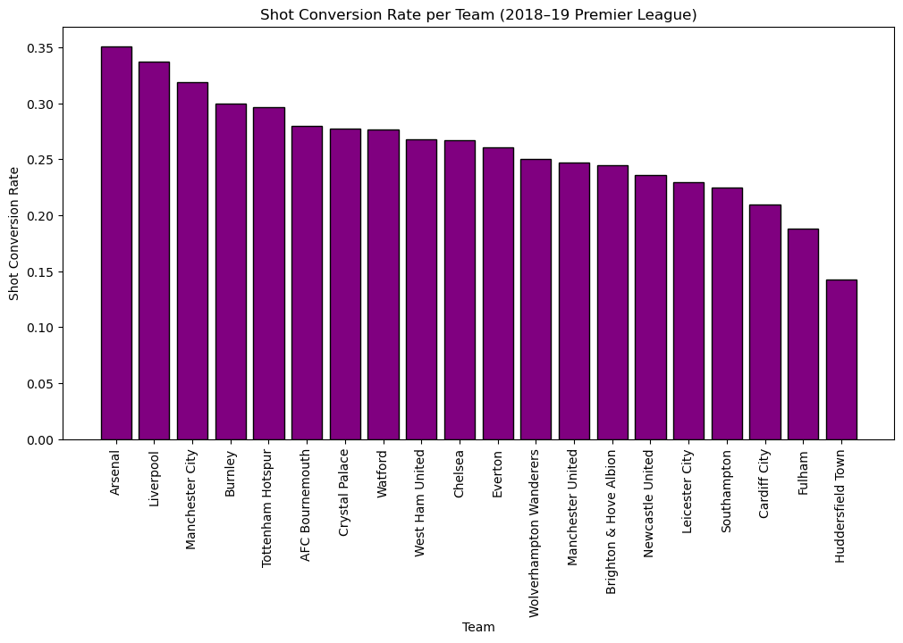

```python
sorted_df = df.sort_values(by='shot_conversion', ascending=False)

plt.figure(figsize=(12, 6))
plt.bar(sorted_df['common_name'], sorted_df['shot_conversion'], color='purple', edgecolor='black')

plt.xlabel('Team')
plt.ylabel('Shot Conversion Rate')
plt.title('Shot Conversion Rate per Team (2018–19 Premier League)')

plt.xticks(rotation=90)
```

Using a barplot, we can visualize every team's shot conversion rate during the 2018-19 season. One of the things we can see from this plot is that there is not a super wide range or standard deviation in the data set, as most teams are tightly clustered right around 0.25, with only a few teams sticking out.

### Analysis of Goals by Interval

One of the things we can look at within the data set is the number of goals scored within different time intervals in games. These are split into 9 different 10 minute intervals, where we can possibly draw some conclusions about strategy and what points of the game are most crucial.

After calling all 9 columns, we can take the mean of each of the columns and print to see which interval results in the most goals scored.

```python
goal_interval_cols = [
    'goals_scored_min_0_to_10',
    'goals_scored_min_11_to_20',
    'goals_scored_min_21_to_30',
    'goals_scored_min_31_to_40',
    'goals_scored_min_41_to_50',
    'goals_scored_min_51_to_60',
    'goals_scored_min_61_to_70',
    'goals_scored_min_71_to_80',
    'goals_scored_min_81_to_90'
]

avg_goals_by_interval = df[goal_interval_cols].mean()

print(avg_goals_by_interval)
```

```
goals_scored_min_0_to_10     4.10
goals_scored_min_11_to_20    5.80
goals_scored_min_21_to_30    5.40
goals_scored_min_31_to_40    4.90
goals_scored_min_41_to_50    5.90
goals_scored_min_51_to_60    5.60
goals_scored_min_61_to_70    6.65
goals_scored_min_71_to_80    5.95
goals_scored_min_81_to_90    9.30
dtype: float64
```

By far, the most goals are scored in the 81st to 90th minutes of a soccer game, with on average a team scoring over 9 goals a season in that time interval. This is likely because it is the very end of the game, and either team may be pushing up extra hard or tactically trying to get a goal more intensely than they were before.

```python
min_labels = ['0–10', '11–20', '21–30', '31–40', '41–50',
                '51–60', '61–70', '71–80', '81–90']
avg_goals_by_interval.index = min_labels
```

In order to clean this data up, we are going to rename each of the columns to just their numerical symbols, for easier presentation once we plot, and for easier reference within the dataset.

The plot below shows a line chart, which charts the average goals scored across each time interval. This further emphasizes the massive increase in the 81-90 time frame, with a sharp jump up compared to any other interval.

```
(3.5, 10.0)
```

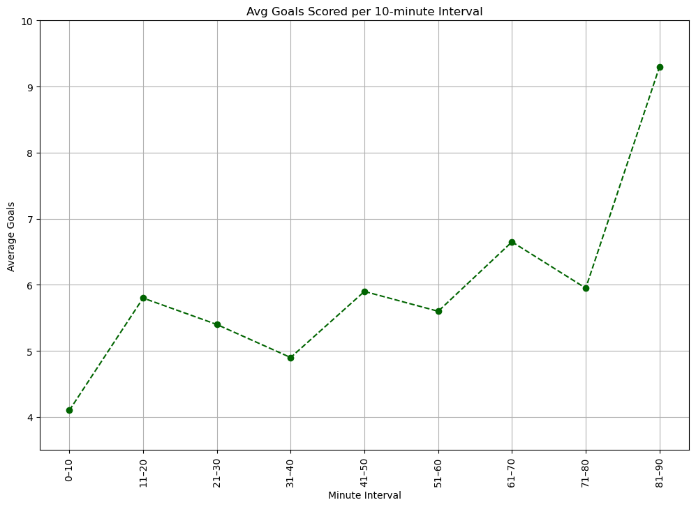

```python
plt.figure(figsize=(12, 8))
plt.plot(avg_goals_by_interval.index, avg_goals_by_interval.values, marker='o', linestyle='--', color='darkgreen')
plt.xticks(rotation=90)

plt.title('Avg Goals Scored per 10-minute Interval')
plt.xlabel('Minute Interval')
plt.ylabel('Average Goals')
plt.grid(True)
plt.ylim(3.5, 10)
```

### Analysis of Manchester City's Goals by Interval

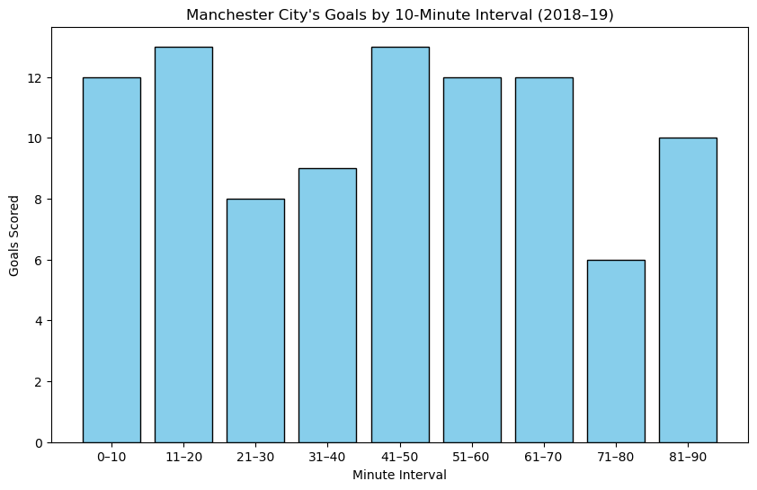

```python
man_city = df[df['common_name'] == 'Manchester City'].iloc[0]

avg_goals_per_interval = man_city[goal_interval_cols].values


plt.figure(figsize=(10, 6))
plt.bar(min_labels, avg_goals_per_interval, color='skyblue', edgecolor='black')

plt.title("Manchester City's Goals by 10-Minute Interval (2018–19)")
plt.xlabel('Minute Interval')
plt.ylabel('Goals Scored')
```

Manchester City won the Premier League in 2018-19, so we decided to specifically look into the spread of when their goals were scored using a bar plot. They do not exactly match the overall spread of goals scored in the league, instead captializing by scoring early in the game, within the first 20 minutes, and then adding on goals early into the second half, specifically between minutes 41-60. This could be an indicator of what is the most optimal time to score goals, since Manchester City were so successful in winning games in this season.

### Correlation Heatmap Analysis

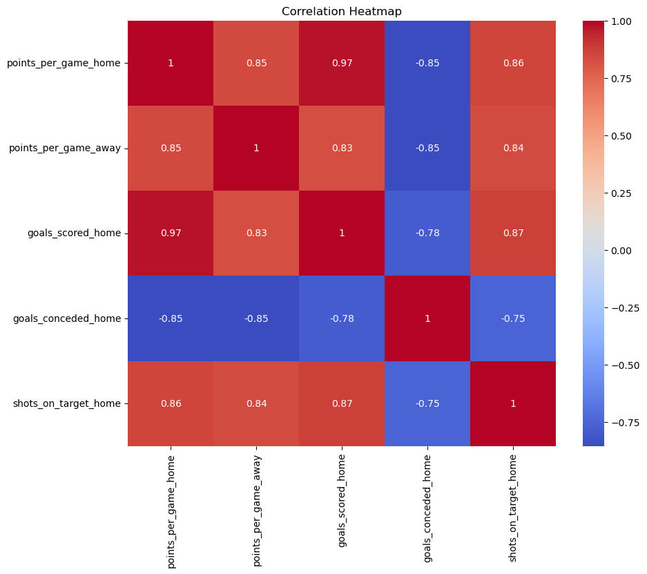

```python
plt.figure(figsize=(10,8))
cols_of_interest = ['points_per_game_home', 'points_per_game_away', 'goals_scored_home', 'goals_conceded_home', 'shots_on_target_home']
sns.heatmap(df[cols_of_interest].corr(), annot=True, cmap='coolwarm')
plt.title("Correlation Heatmap")
plt.show()
```

The heatmap above visualizes the correlation between key performance metrics from the 2018–2019 Premier League season. Specifically, it focuses on:

- `points_per_game_home`
- `points_per_game_away`
- `goals_scored_home`
- `goals_conceded_home`
- `shots_on_target_home`

These variables are important in evaluating how attacking and defensive stats relate to team success.

The color gradient (`coolwarm`) visually distinguishes the strength and direction of the correlations. Red cells indicate strong positive correlations, while blue cells indicate negative correlations. The correlation coefficients are also displayed in each cell for numerical clarity.

From the heatmap, we can identify which factors are most strongly associated with earning more points at home. For example, a strong positive correlation between `goals_scored_home` and `points_per_game_home` would suggest that teams who score more at home tend to secure better results. Conversely, a negative correlation between `goals_conceded_home` and `points_per_game_home` would indicate that conceding fewer goals is also critical for success.

This analysis helps highlight the statistical relationships between a team's offensive and defensive efforts and their overall performance.

### Final Analysis and Conclusion

This analysis of the Premier League 2018–2019 season reveals key factors that influenced team performance, particularly when comparing home and away statistics. Through our home vs. away points per game comparison, we observed that many top-performing teams, such as Manchester City, Liverpool, and Arsenal, benefited from a strong home advantage. These teams consistently earned more points at home, suggesting that home-field factors like fan support, tactical familiarity, and reduced travel fatigue played a significant role in their success. Conversely, some teams, such as Crystal Palace, exhibited stronger away performances, indicating unique tactical adaptability or pressure differences in home environments.

When examining the relationship between home goals and points per game, a clear upward trend emerged. Teams that scored more goals at home also tended to earn significantly more points. This finding emphasizes the importance of offensive effectiveness in determining match outcomes, especially when playing on home turf. High-performing clubs were not only able to defend their home stadiums but also capitalize on scoring opportunities, directly translating to better league standings.

The correlation heatmap further supported these observations by showing strong positive relationships between home points per game and variables like goals scored and shots on target. At the same time, we saw negative correlations with goals conceded, reinforcing the value of a balanced strategy: both scoring frequently and defending effectively are essential for consistent success.

In summary, this project highlights that home performance, driven by scoring efficiency and defensive discipline, is a key contributor to a team’s overall success in the Premier League. Statistical analysis confirms that strong attacking output at home and the ability to limit goals conceded are both highly predictive of strong point returns. These insights not only explain team outcomes in 2018–2019 but also offer valuable lessons for future performance analysis and tactical evaluation.

This analysis of the Premier League 2018–2019 season reveals key factors that influenced team performance, particularly when comparing home and away statistics. Through our home vs. away points per game comparison, we observed that many top-performing teams, such as Manchester City, Liverpool, and Arsenal, benefited from a strong home advantage. These teams consistently earned more points at home, suggesting that home-field factors like fan support, tactical familiarity, and reduced travel fatigue played a significant role in their success. Conversely, some teams, such as Crystal Palace, exhibited stronger away performances, indicating unique tactical adaptability or pressure differences in home environments.

When examining the relationship between home goals and points per game, a clear upward trend emerged. Teams that scored more goals at home also tended to earn significantly more points. This finding emphasizes the importance of offensive effectiveness in determining match outcomes, especially when playing on home turf. High-performing clubs were not only able to defend their home stadiums but also capitalize on scoring opportunities, directly translating to better league standings.

Goal difference is one of the most important stats in soccer, as exemplified by this project. Goal difference correlates heavily to league position, and having a large gap between your goals scored and goals allowed is the best way to end up high on a league position table.

Getting a high rate of shots on target is a crucial part of consistently scoring goals and being successful in the Premier League. This is exemplified through teams like Manchester United, Liverpool, and Manchester City dominating the shot accuracy leaderboard, while also being very successful in scoring goals and picking up points. This is further built upon through shot conversion rate, which measures whether these shots on target are actually goals are not. Teams that struggled in this area, like Fulham and Cardiff City, struggled to win games due to their inability to score goals.

Investigating goals scored across different time intervals allowed us to take a different perspective on how games are won in the Premier League. By plotting and observing these data points, we were able to conclude that most goals were scored at the very end of games, which suggests a strategy of many teams going more offensive as the game winds down. Despite this, a successful team like Manchester City won the Premier League by scoring early and controlling the game.

The correlation heatmap further supported these observations by showing strong positive relationships between home points per game and variables like goals scored and shots on target. At the same time, we saw negative correlations with goals conceded, reinforcing the value of a balanced strategy: both scoring frequently and defending effectively are essential for consistent success.

In summary, this project highlights that home performance, driven by scoring efficiency and defensive discipline, is a key contributor to a team’s overall success in the Premier League. It also exemplifies how underlying statistics like goal difference, shot accuracy, and the ability to score goals across different intervals of the game contribute to success. Statistical analysis confirms that strong attacking output at home and the ability to limit goals conceded are both highly predictive of strong point returns. These insights not only explain team outcomes in 2018–2019 but also offer valuable lessons for future performance analysis and tactical evaluation.

### Dataset Citation

Website Source:

[https://footystats.org/download-stats-csv](https://urldefense.com/v3/__https://footystats.org/download-stats-csv__;!!IKRxdwAv5BmarQ!atQX_sXq_1oN_jhgOl6YhVCq3iqJgbxB1QfnhFL3ZT6auiRCQqtqD6pXTdFw2Yc4P0FCF1O6Xpq2SV5M9g$)